# Case Study - Bike Share

Andrea

2/6/2021

This is a case study of a bike sharing company that wants his marketing department to create campaigns targeting his casual riders so that some of they could become members, customers of the annual membership.

## Business Task

The business task is understand the behavior of both types of customers: casual riders and members. Understand the differences in their use of the services so that the company can maximize the number of member (more profitable users for the company).

## Data sources

All data is anonymous, there is no personal data from riders.

## Data cleaning

Load packages to be used.

```r
library(tidyverse)
library(lubridate)
```

```r
library(ggplot2)
```

```r
X202004_divvy_tripdata <- read_csv("202004-divvy-tripdata.csv")
X202005_divvy_tripdata <- read_csv("202005-divvy-tripdata.csv")
X202006_divvy_tripdata <- read_csv("202006-divvy-tripdata.csv")
X202007_divvy_tripdata <- read_csv("202007-divvy-tripdata.csv")
X202008_divvy_tripdata <- read_csv("202008-divvy-tripdata.csv")
X202009_divvy_tripdata <- read_csv("202009-divvy-tripdata.csv")
X202010_divvy_tripdata <- read_csv("202010-divvy-tripdata.csv")
X202011_divvy_tripdata <- read_csv("202011-divvy-tripdata.csv")
X202012_divvy_tripdata <- read_csv("202012-divvy-tripdata.csv")
X202101_divvy_tripdata <- read_csv("202101-divvy-tripdata.csv")
X202102_divvy_tripdata <- read_csv("202102-divvy-tripdata.csv")
X202103_divvy_tripdata <- read_csv("202103-divvy-tripdata.csv")
X202104_divvy_tripdata <- read_csv("202104-divvy-tripdata.csv")
```

Mutate the format of start station and end station into character in the files that has a double format

```r
X202011_divvy_tripdata <-  mutate(X202011_divvy_tripdata,
                                  start_station_id = as.character(start_station_id),
                                  end_station_id = as.character(end_station_id))
X202010_divvy_tripdata <-  mutate(X202010_divvy_tripdata,
                                  start_station_id = as.character(start_station_id),
                                  end_station_id = as.character(end_station_id))
X202009_divvy_tripdata <-  mutate(X202009_divvy_tripdata,
                                  start_station_id = as.character(start_station_id),
                                  end_station_id = as.character(end_station_id))
X202008_divvy_tripdata <-  mutate(X202008_divvy_tripdata,
                                  start_station_id = as.character(start_station_id),
                                  end_station_id = as.character(end_station_id))
X202007_divvy_tripdata <-  mutate(X202007_divvy_tripdata,
                                  start_station_id = as.character(start_station_id),
                                  end_station_id = as.character(end_station_id))
X202006_divvy_tripdata <-  mutate(X202006_divvy_tripdata,
                                  start_station_id = as.character(start_station_id),
                                  end_station_id = as.character(end_station_id))
X202005_divvy_tripdata <-  mutate(X202005_divvy_tripdata,
                                  start_station_id = as.character(start_station_id),
                                  end_station_id = as.character(end_station_id))
X202004_divvy_tripdata <-  mutate(X202004_divvy_tripdata,
                                  start_station_id = as.character(start_station_id),
                                  end_station_id = as.character(end_station_id))
```

Join all data frames

```r
all_trips <- bind_rows(X202004_divvy_tripdata, X202005_divvy_tripdata, X202006_divvy_tripdata,
                       X202007_divvy_tripdata, X202008_divvy_tripdata, X202009_divvy_tripdata,
                       X202010_divvy_tripdata, X202011_divvy_tripdata, X202012_divvy_tripdata,
                       X202101_divvy_tripdata, X202102_divvy_tripdata, X202103_divvy_tripdata,
                       X202104_divvy_tripdata)
```

Inspect the dataset to see columns, structure, formats and summary

```r
colnames(all_trips)
```

```
##  [1] "ride_id"            "rideable_type"      "started_at"
##  [4] "ended_at"           "start_station_name" "start_station_id"
##  [7] "end_station_name"   "end_station_id"     "start_lat"
## [10] "start_lng"          "end_lat"            "end_lng"
## [13] "member_casual"
```

```r
nrow(all_trips)
```

```
## [1] 3826978
```

```r
dim(all_trips)
```

```
## [1] 3826978      13
```

```r
head(all_trips)
```

```
## # A tibble: 6 x 13
##   ride_id rideable_type started_at          ended_at            start_station_n~
##   <chr>   <chr>         <dttm>              <dttm>              <chr>
## 1 A847FA~ docked_bike   2020-04-26 17:45:14 2020-04-26 18:12:03 Eckhart Park
## 2 5405B8~ docked_bike   2020-04-17 17:08:54 2020-04-17 17:17:03 Drake Ave & Ful~
## 3 5DD24A~ docked_bike   2020-04-01 17:54:13 2020-04-01 18:08:36 McClurg Ct & Er~
## 4 2A59BB~ docked_bike   2020-04-07 12:50:19 2020-04-07 13:02:31 California Ave ~
## 5 27AD30~ docked_bike   2020-04-18 10:22:59 2020-04-18 11:15:54 Rush St & Hubba~
## 6 356216~ docked_bike   2020-04-30 17:55:47 2020-04-30 18:01:11 Mies van der Ro~
## # ... with 8 more variables: start_station_id <chr>, end_station_name <chr>,
## #   end_station_id <chr>, start_lat <dbl>, start_lng <dbl>, end_lat <dbl>,
## #   end_lng <dbl>, member_casual <chr>
```

```r
str(all_trips)
```

```
## spec_tbl_df [3,826,978 x 13] (S3: spec_tbl_df/tbl_df/tbl/data.frame)
##  $ ride_id           : chr [1:3826978] "A847FADBBC638E45" "5405B80E996FF60D" "5DD24A79A4E006F4" "2A59BBDF5CDBA725" ...
##  $ rideable_type     : chr [1:3826978] "docked_bike" "docked_bike" "docked_bike" "docked_bike" ...
##  $ started_at        : POSIXct[1:3826978], format: "2020-04-26 17:45:14" "2020-04-17 17:08:54" ...
##  $ ended_at          : POSIXct[1:3826978], format: "2020-04-26 18:12:03" "2020-04-17 17:17:03" ...
##  $ start_station_name: chr [1:3826978] "Eckhart Park" "Drake Ave & Fullerton Ave" "McClurg Ct & Erie St" "California Ave & Division St" ...
##  $ start_station_id  : chr [1:3826978] "86" "503" "142" "216" ...
##  $ end_station_name  : chr [1:3826978] "Lincoln Ave & Diversey Pkwy" "Kosciuszko Park" "Indiana Ave & Roosevelt Rd" "Wood St & Augusta Blvd" ...
##  $ end_station_id    : chr [1:3826978] "152" "499" "255" "657" ...
##  $ start_lat         : num [1:3826978] 41.9 41.9 41.9 41.9 41.9 ...
##  $ start_lng         : num [1:3826978] -87.7 -87.7 -87.6 -87.7 -87.6 ...
##  $ end_lat           : num [1:3826978] 41.9 41.9 41.9 41.9 42 ...
##  $ end_lng           : num [1:3826978] -87.7 -87.7 -87.6 -87.7 -87.7 ...
##  $ member_casual     : chr [1:3826978] "member" "member" "member" "member" ...
##  - attr(*, "spec")=
##   .. cols(
##   ..   ride_id = col_character(),
##   ..   rideable_type = col_character(),
##   ..   started_at = col_datetime(format = ""),
##   ..   ended_at = col_datetime(format = ""),
##   ..   start_station_name = col_character(),
##   ..   start_station_id = col_double(),
##   ..   end_station_name = col_character(),
##   ..   end_station_id = col_double(),
##   ..   start_lat = col_double(),
##   ..   start_lng = col_double(),
##   ..   end_lat = col_double(),
##   ..   end_lng = col_double(),
##   ..   member_casual = col_character()
##   .. )
```

```r
summary(all_trips)
```

```
##    ride_id          rideable_type        started_at
##  Length:3826978     Length:3826978     Min.   :2020-04-01 00:00:30
##  Class :character   Class :character   1st Qu.:2020-07-19 19:42:40
##  Mode  :character   Mode  :character   Median :2020-09-06 18:00:14
##                                        Mean   :2020-09-29 06:10:30
##                                        3rd Qu.:2020-11-12 16:42:46
##                                        Max.   :2021-04-30 23:59:53
##
##     ended_at                   start_station_name start_station_id
##  Min.   :2020-04-01 00:10:45   Length:3826978     Length:3826978
##  1st Qu.:2020-07-19 20:22:24   Class :character   Class :character
##  Median :2020-09-06 18:30:35   Mode  :character   Mode  :character
##  Mean   :2020-09-29 06:35:12
##  3rd Qu.:2020-11-12 16:58:25
##  Max.   :2021-05-05 22:14:39
##
##  end_station_name   end_station_id       start_lat       start_lng
##  Length:3826978     Length:3826978     Min.   :41.64   Min.   :-87.87
##  Class :character   Class :character   1st Qu.:41.88   1st Qu.:-87.66
##  Mode  :character   Mode  :character   Median :41.90   Median :-87.64
##                                        Mean   :41.90   Mean   :-87.64
##                                        3rd Qu.:41.93   3rd Qu.:-87.63
##                                        Max.   :42.08   Max.   :-87.52
##
##     end_lat         end_lng       member_casual
##  Min.   :41.54   Min.   :-88.07   Length:3826978
##  1st Qu.:41.88   1st Qu.:-87.66   Class :character
##  Median :41.90   Median :-87.64   Mode  :character
##  Mean   :41.90   Mean   :-87.64
##  3rd Qu.:41.93   3rd Qu.:-87.63
##  Max.   :42.16   Max.   :-87.44
##  NA's   :5005    NA's   :5005
```

Add columns that list the date, month, day, and year of each ride so that later we can agregate by them

```r
all_trips$date <- as.Date(all_trips$started_at)
all_trips$month <- format(as.Date(all_trips$date), "%m")
all_trips$day <- format(as.Date(all_trips$date), "%d")
all_trips$year <- format(as.Date(all_trips$date), "%Y")
all_trips$day_of_week <- format(as.Date(all_trips$date), "%A")
```

Add a ride_length calculation to all_trips (in seconds) and check all new fields

```r
all_trips$ride_length <- difftime(all_trips$ended_at,all_trips$started_at)
all_trips %>%
  select(date, month, day, year, day_of_week, ride_length)
```

```
## # A tibble: 3,826,978 x 6
##    date       month day   year  day_of_week ride_length
##    <date>     <chr> <chr> <chr> <chr>       <drtn>
##  1 2020-04-26 04    26    2020  domingo     1609 secs
##  2 2020-04-17 04    17    2020  viernes      489 secs
##  3 2020-04-01 04    01    2020  miércoles    863 secs
##  4 2020-04-07 04    07    2020  martes       732 secs
##  5 2020-04-18 04    18    2020  sábado      3175 secs
##  6 2020-04-30 04    30    2020  jueves       324 secs
##  7 2020-04-02 04    02    2020  jueves       313 secs
##  8 2020-04-07 04    07    2020  martes      4549 secs
##  9 2020-04-15 04    15    2020  miércoles    344 secs
## 10 2020-04-04 04    04    2020  sábado      1039 secs
## # ... with 3,826,968 more rows
```

Convert “ride_length” from Factor to numeric so we can run calculations on the data

```r
all_trips$ride_length <- as.numeric(as.character(all_trips$ride_length))
is.numeric(all_trips$ride_length)
```

```
## [1] TRUE
```

Remove bad data (quality check trips and rows with ride_length negative) and create a new version

```r
all_trips_v2 <- all_trips[!(all_trips$start_station_name == "HQ QR" | all_trips$ride_length<0),]
```

Created a new data frame with all the duplicates from the last version to check that all have ride_id with value NA

```r
duplicates <- data.frame(ride_id = all_trips_v2$ride_id , dup_indicator = duplicated(all_trips_v2$ride_id),
                         started_at = all_trips_v2$started_at, ended_at = all_trips_v2$ended_at)
head(filter(duplicates, dup_indicator=="TRUE"))
```

```
##   ride_id dup_indicator started_at ended_at
## 1    <NA>          TRUE       <NA>     <NA>
## 2    <NA>          TRUE       <NA>     <NA>
## 3    <NA>          TRUE       <NA>     <NA>
## 4    <NA>          TRUE       <NA>     <NA>
## 5    <NA>          TRUE       <NA>     <NA>
## 6    <NA>          TRUE       <NA>     <NA>
```

## Analysis

Descriptive analysis on ride_length (all figures in seconds)

```r
summary(all_trips_v2$ride_length)
```

```
##    Min. 1st Qu.  Median    Mean 3rd Qu.    Max.    NA's
##       0     479     874    1686    1602 3523202  148183
```

Compare members and casual users

```r
aggregate(all_trips_v2$ride_length ~ all_trips_v2$member_casual, FUN = mean)
```

```
##   all_trips_v2$member_casual all_trips_v2$ride_length
## 1                     casual                2717.6094
## 2                     member                 966.1052
```

```r
aggregate(all_trips_v2$ride_length ~ all_trips_v2$member_casual, FUN = median)
```

```
##   all_trips_v2$member_casual all_trips_v2$ride_length
## 1                     casual                     1278
## 2                     member                      689
```

```r
aggregate(all_trips_v2$ride_length ~ all_trips_v2$member_casual, FUN = max)
```

```
##   all_trips_v2$member_casual all_trips_v2$ride_length
## 1                     casual                  3341033
## 2                     member                  3523202
```

```r
aggregate(all_trips_v2$ride_length ~ all_trips_v2$member_casual, FUN = min)
```

```
##   all_trips_v2$member_casual all_trips_v2$ride_length
## 1                     casual                        0
## 2                     member                        0
```

See the average ride time and number of rides by each day for members vs casual users

```r
aggregate(all_trips_v2$ride_length ~ all_trips_v2$member_casual + all_trips_v2$day_of_week, FUN = mean)
```

```
##    all_trips_v2$member_casual all_trips_v2$day_of_week all_trips_v2$ride_length
## 1                      casual                  domingo                3053.4045
## 2                      member                  domingo                1095.5406
## 3                      casual                   jueves                2562.8716
## 4                      member                   jueves                 908.3416
## 5                      casual                    lunes                2715.2761
## 6                      member                    lunes                 921.1990
## 7                      casual                   martes                2477.4782
## 8                      member                   martes                 909.7689
## 9                      casual                miércoles                2466.9220
## 10                     member                miércoles                 915.2750
## 11                     casual                   sábado                2817.0078
## 12                     member                   sábado                1070.2137
## 13                     casual                  viernes                2615.8820
## 14                     member                  viernes                 945.1852
```

```r
aggregate(all_trips_v2$ride_length ~ all_trips_v2$member_casual + all_trips_v2$day_of_week, FUN = length)
```

```
##    all_trips_v2$member_casual all_trips_v2$day_of_week all_trips_v2$ride_length
## 1                      casual                  domingo                   278706
## 2                      member                  domingo                   278734
## 3                      casual                   jueves                   171461
## 4                      member                   jueves                   315424
## 5                      casual                    lunes                   160437
## 6                      member                    lunes                   282837
## 7                      casual                   martes                   158627
## 8                      member                   martes                   303177
## 9                      casual                miércoles                   163295
## 10                     member                miércoles                   317753
## 11                     casual                   sábado                   351844
## 12                     member                   sábado                   335564
## 13                     casual                  viernes                   222434
## 14                     member                  viernes                   327945
```

Analyze ridership data by user type and weekday

```r
all_trips_v2 %>%
  group_by(member_casual, day_of_week) %>%
  summarise(number_of_rides = n()
            ,average_duration = mean(ride_length)) %>%
  arrange(member_casual, day_of_week)
```

```
## # A tibble: 15 x 4
## # Groups:   member_casual [3]
##    member_casual day_of_week number_of_rides average_duration
##    <chr>         <chr>                 <int>            <dbl>
##  1 casual        domingo              278706            3053.
##  2 casual        jueves               171461            2563.
##  3 casual        lunes                160437            2715.
##  4 casual        martes               158627            2477.
##  5 casual        miércoles            163295            2467.
##  6 casual        sábado               351844            2817.
##  7 casual        viernes              222434            2616.
##  8 member        domingo              278734            1096.
##  9 member        jueves               315424             908.
## 10 member        lunes                282837             921.
## 11 member        martes               303177             910.
## 12 member        miércoles            317753             915.
## 13 member        sábado               335564            1070.
## 14 member        viernes              327945             945.
## 15 <NA>          <NA>                 148183              NA
```

From this information you can conclude that:

## Visualizations

Number of rides by rider type and day of the week

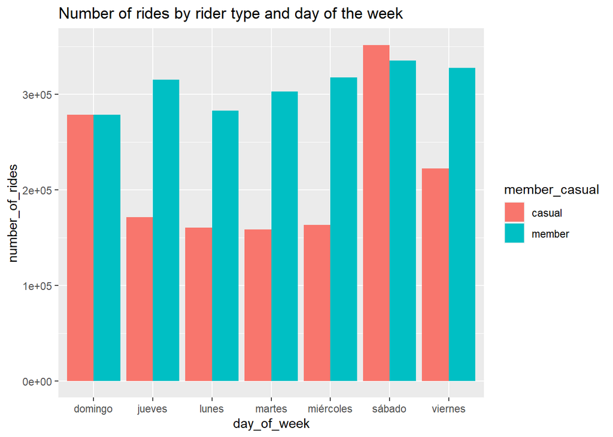

```r
all_trips_v2 %>%
  group_by(member_casual, day_of_week) %>%
  summarise(number_of_rides = n()
            ,average_duration = mean(ride_length)) %>%
  drop_na(day_of_week) %>%
  arrange(member_casual, day_of_week)  %>%
  ggplot(aes(x = day_of_week, y = number_of_rides, fill = member_casual)) +
  geom_col(position = "dodge") +
  labs(title = "Number of rides by rider type and day of the week")
```

Average duration of rides by rider type and day of the week

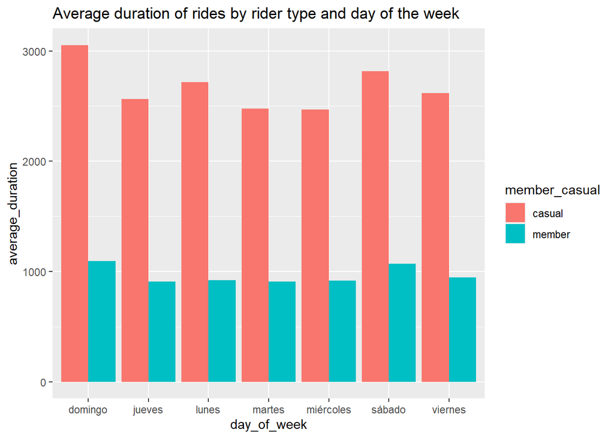

```r
all_trips_v2 %>%
  group_by(member_casual, day_of_week) %>%
  summarise(number_of_rides = n()
            ,average_duration = mean(ride_length)) %>%
  drop_na(day_of_week) %>%
  arrange(member_casual, day_of_week)  %>%
  ggplot(aes(x = day_of_week, y = average_duration, fill = member_casual)) +
  geom_col(position = "dodge") +
  labs(title = "Average duration of rides by rider type and day of the week")
```

Create a summary csv for use in other software

```r
res <- all_trips_v2 %>%
  group_by(member_casual, day_of_week) %>%
  summarise(number_of_rides = n()
            ,average_duration = mean(ride_length)) %>%
  drop_na(day_of_week) %>%
  arrange(member_casual, day_of_week)
write.csv(res, file = "res.csv")
```

## Recomendations for the marketing team

### Where should their digital (social media, email and other) campaigns focus

- Encourage casual riders to use the service regularly for work or school.
- Encourage causal riders to use the service for shorter rides (run errands, dates etc.) reminding of the benefits of using it instead of other means of transportation.
- Equate the biking service as other mean of transport so it can be used on a daily basis, not only for leisure.